# 🏎️ Nina's F1 Predictions: 2026 Japanese Grand Prix (Round 3)

## Suzuka Circuit — March 27-29, 2026

### What This Is

A machine learning model that predicts Formula 1 race results and optimizes F1 Fantasy lineups. The model analyzes 24 different factors — the same kinds of data a race engineer would consider when building a race strategy — and runs 10,000 simulated races to estimate each driver's probability of finishing on the podium, in the points, or beating their teammate.

### The 24 Features

The model looks at every driver through these lenses:

**Car Performance (2026 only):**

- 🏗️ Constructor pace — average finish position by team this season
- ⚡ Straight-line speed — speed trap data, critical for Suzuka's 1.2km back straight

**Driver Skill (all years, car-independent):**

- 👤 Teammate delta — how much better/worse than their teammate
- 📊 Recent form — rolling average finish position
- 🚀 First lap performance — who consistently gains/loses positions at the start
- 📈 Season momentum — are they trending up or down? (uses current team only for drivers who switched)
- 🎯 Positions gained per race — racecraft and overtaking ability
- ⏱️ Qualifying vs race pace — "Saturday car" vs "Sunday car"

**Tire & Strategy:**

- 🛞 Tire degradation rate — who's gentle on tires (longer stints, fewer stops)
- 🔧 Pit stop frequency — driver and team pit stop patterns

**Track-Specific (Suzuka):**

- 🗾 Sector 1 pace — technical corners through The Esses
- 🗾 Sector 2 pace — power sector (back straight + Degner curves)
- 🗾 Sector 3 pace — mixed character (Spoon, 130R, chicane)
- 🏁 Track experience — how many times they've raced here

**Conditions & Context:**

- 🌡️ Weather — temperature, humidity, rainfall
- 🌧️ Wet-weather skill — positions gained in historical rain races
- 🟡 Safety car — 33% probability at Suzuka, wired into simulations
- 🔄 Team changed — 9 of 22 drivers switched teams for 2026 (adds uncertainty)
- 📋 Consistency — lap time variation (lower = more reliable)
- 🏎️ DNF rate — reliability factor
- 🔬 2026 flag — tells the model this is a regulation-change year

## 1. New Feature Deep Dive

Four charts showing what makes each driver unique — their first-lap performance (who gains positions at the start), how gently they treat their tires, whether they're trending up or down this season, and how fast their car is on the straights. These differences matter at Suzuka.

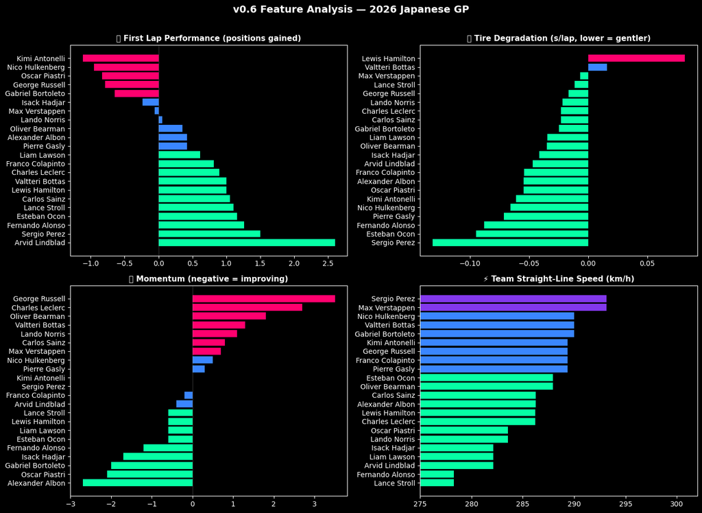

## 2. Suzuka Sector Analysis

Suzuka has three distinct sectors that test different car characteristics:

- **S1 (Turns 1-9):** High-speed technical corners through 'The Esses' — rewards downforce and driver confidence
- **S2 (Back straight + Degner):** Pure power — the 1.2km straight is where active aero overtakes happen
- **S3 (Spoon, 130R, chicane):** Mixed character — late braking and car balance

```
===========================================================================
  🗾 SUZUKA SECTOR PROFILES — Who's Fast Where?
===========================================================================

  S1: Technical (The Esses) | S2: Power (Back Straight) | S3: Mixed

  Driver                   S1 (tech)   S2 (power)   S3 (mixed)  Best Sector
  ----------------------------------------------------------------------
  George Russell             -0.191s      -0.067s      -0.010s  S1
  Kimi Antonelli             -2.128s      -1.042s      -0.576s  S1
  Charles Leclerc            -0.210s      -0.227s      -0.077s  S2
  Lewis Hamilton             -0.231s      -0.121s      -0.057s  S1
  Lando Norris               -0.503s      -0.354s      -0.079s  S1
  Max Verstappen             -0.584s      -0.487s      -0.154s  S1
  Oliver Bearman             -1.925s      -0.768s      -0.379s  S1
  Arvid Lindblad             no data      no data      no data  No Suzuka data
  Gabriel Bortoleto          -1.586s      -0.641s      -0.396s  S1
  Pierre Gasly               +0.466s      +0.270s      +0.138s  S3
  Esteban Ocon               +0.575s      +0.374s      +0.174s  S3
  Alexander Albon            +0.005s      +0.208s      +0.109s  S1
  Liam Lawson                -0.025s      +0.119s      +0.037s  S1
  Franco Colapinto           no data      no data      no data  No Suzuka data
  Carlos Sainz               -0.098s      -0.097s      -0.099s  S3
  Sergio Perez               +0.892s      +0.674s      +0.322s  S3
  Lance Stroll               +0.283s      +0.226s      +0.192s  S3
  Fernando Alonso            -0.093s      -0.079s      +0.061s  S1
  Valtteri Bottas            +1.903s      +0.675s      +0.233s  S3
  Isack Hadjar               -1.995s      -0.943s      -0.475s  S1
  Oscar Piastri              -0.377s      -0.241s      -0.006s  S1
  Nico Hulkenberg            +0.215s      +0.178s      +0.020s  S3
```

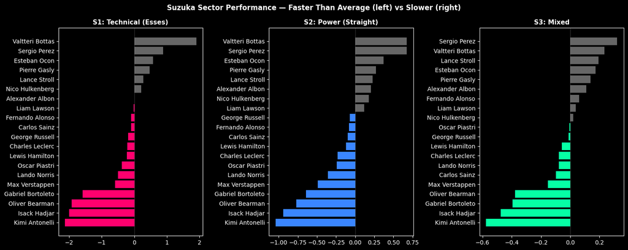

## 3. Car Pace (2026 Only)

```
======================================================================
  🏗️ CONSTRUCTOR PACE (2026 Only)
======================================================================

  Team                     Avg Fin   Speed  Tier
  --------------------------------------------------
  Mercedes                P   4.1   289  Tier 2
  Ferrari                 P   5.2   286  Tier 2
  Alpine                  P  10.5   289  Tier 3
  McLaren                 P  10.8   284  Tier 3
  Red Bull Racing         P  10.8   293  Tier 3
  Racing Bulls            P  11.4   282  Tier 3
  Haas F1 Team            P  12.2   288  Tier 4
  Williams                P  13.8   286  Tier 4
  Audi                    P  13.9   279  Tier 4
  Cadillac                P  16.8   278  Tier 5
  Aston Martin            P  17.0   278  Tier 5
```

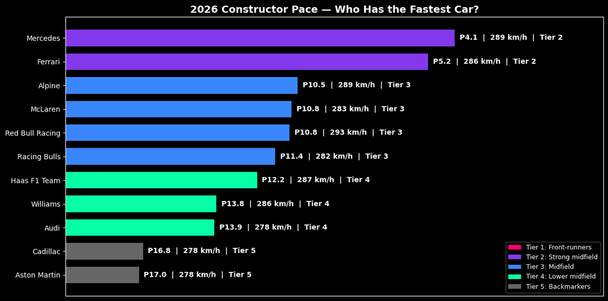

## 3b. FP1 Practice Data (Live)

Actual practice session data from Suzuka, pulled via FastF1. This updates car pace and speed estimates with real 2026 Suzuka performance, and provides actual weather conditions for the prediction model.

[output not shown]

[output not shown]

[output not shown]

[output not shown]

[output not shown]

[output not shown]

[output not shown]

[output not shown]

[output not shown]

[output not shown]

[output not shown]

[output not shown]

[output not shown]

```
================================================================================
  🏁 FP1 RESULTS — Suzuka (Live Data)
================================================================================

  Pos  Driver                  Team                Best Lap       Gap  Top Spd
  ------------------------------------------------------------------------
  P 1  George Russell          Mercedes          1:31.666   FASTEST    285
  P 2  Kimi Antonelli          Mercedes          1:31.692    +0.026    285
  P 3  Lando Norris            McLaren           1:31.798    +0.132    281
  P 4  Oscar Piastri           McLaren           1:31.865    +0.199    297
  P 5  Charles Leclerc         Ferrari           1:31.955    +0.289    290
  P 6  Lewis Hamilton          Ferrari           1:32.040    +0.374    284
  P 7  Max Verstappen          Red Bull Racing   1:32.457    +0.791    290
  P 8  Liam Lawson             Racing Bulls      1:32.529    +0.863    286
  P 9  Esteban Ocon            Haas F1 Team      1:32.601    +0.935    281
  P10  Arvid Lindblad          Racing Bulls      1:32.665    +0.999    297
  P11  Gabriel Bortoleto       Audi              1:32.759    +1.093    286
  P12  Nico Hulkenberg         Audi              1:32.798    +1.132    284
  P13  Isack Hadjar            Red Bull Racing   1:32.803    +1.137    290
  P14  Oliver Bearman          Haas F1 Team      1:32.900    +1.234    281
  P15  Pierre Gasly            Alpine            1:32.978    +1.312    291
  P16  Franco Colapinto        Alpine            1:33.361    +1.695    284
  P17  Carlos Sainz            Williams          1:33.383    +1.717    294
  P18  Alexander Albon         Williams          1:33.697    +2.031    281
  P19  Sergio Perez            Cadillac          1:34.221    +2.555    288
  P20  Valtteri Bottas         Cadillac          1:34.490    +2.824    293
  P21  Lance Stroll            Aston Martin      1:35.294    +3.628    277
  P22  Jak Crawford            Aston Martin      1:36.362    +4.696    269

  📊 BLENDED CAR PACE (60% season + 40% FP1):
  Team                     Season    FP1   Blended  FP1 Spd
  -------------------------------------------------------
  Mercedes                P  4.1  P1.5  P   3.0     288
  Ferrari                 P  5.2  P5.5  P   5.3     287
  Alpine                  P 10.5  P15.5  P  12.5     289
  McLaren                 P 10.8  P3.5  P   7.9     286
  Red Bull Racing         P 10.8  P9.5  P  10.3     292
  Racing Bulls            P 11.4  P7.5  P   9.8     286
  Haas F1 Team            P 12.2  P11.5  P  11.9     285
  Williams                P 13.8  P17.5  P  15.3     287
  Audi                    P 13.9  P13.5  P  13.8     281
  Cadillac                P 16.8  P19.5  P  17.9     283
  Aston Martin            P 17.0  P21.5  P  18.8     276

  🌡️ Actual conditions: 16.4°C, 49% humidity, DRY

  🛞 TIRE STINTS:
  George Russell          HARD(17), SOFT(10)
  Kimi Antonelli          HARD(12), SOFT(14)
  Lando Norris            MEDIUM(11), SOFT(9)
  Oscar Piastri           MEDIUM(17), SOFT(6)
  Charles Leclerc         HARD(10), SOFT(15)
  Lewis Hamilton          HARD(11), SOFT(12)
  Max Verstappen          MEDIUM(21), SOFT(6)
  Liam Lawson             HARD(11), SOFT(16)
  Esteban Ocon            HARD(17), SOFT(6)
  Arvid Lindblad          HARD(19), SOFT(10)
```

## 3c. FP2 Practice Data (Live)

Second practice session — longer runs, race fuel simulations, and more representative pace. FP2 gets the highest weight in the blend since it best reflects race conditions.

**Updated blend: 30% season + 30% FP1 + 40% FP2**

[output not shown]

[output not shown]

[output not shown]

[output not shown]

[output not shown]

[output not shown]

[output not shown]

[output not shown]

[output not shown]

[output not shown]

[output not shown]

[output not shown]

[output not shown]

```
================================================================================
  🏁 FP2 RESULTS — Suzuka (Live Data)
================================================================================

  Pos  Driver                  Team                Best Lap       Gap  Top Spd
  ------------------------------------------------------------------------
  P 1  Oscar Piastri           McLaren           1:30.133   FASTEST    292
  P 2  Kimi Antonelli          Mercedes          1:30.225    +0.092    288
  P 3  George Russell          Mercedes          1:30.338    +0.205    281
  P 4  Lando Norris            McLaren           1:30.649    +0.516    289
  P 5  Charles Leclerc         Ferrari           1:30.846    +0.713    293
  P 6  Lewis Hamilton          Ferrari           1:30.980    +0.847    280
  P 7  Nico Hulkenberg         Audi              1:31.441    +1.308    295
  P 8  Alexander Albon         Williams          1:31.496    +1.363    285
  P 9  Oliver Bearman          Haas F1 Team      1:31.498    +1.365    295
  P10  Max Verstappen          Red Bull Racing   1:31.509    +1.376    288
  P11  Esteban Ocon            Haas F1 Team      1:31.532    +1.399    283
  P12  Liam Lawson             Racing Bulls      1:31.590    +1.457    289
  P13  Carlos Sainz            Williams          1:31.608    +1.475    289
  P14  Pierre Gasly            Alpine            1:31.734    +1.601    291
  P15  Isack Hadjar            Red Bull Racing   1:31.759    +1.626    284
  P16  Gabriel Bortoleto       Audi              1:31.933    +1.800    284
  P17  Franco Colapinto        Alpine            1:32.438    +2.305    288
  P18  Valtteri Bottas         Cadillac          1:32.615    +2.482    290
  P19  Fernando Alonso         Aston Martin      1:33.596    +3.463    288
  P20  Sergio Perez            Cadillac          1:33.689    +3.556    286
  P21  Lance Stroll            Aston Martin      1:33.951    +3.818    280

  📊 BLENDED CAR PACE (30% season + 30% FP1 + 40% FP2):
  Team                     Season    FP1    FP2   Blended  FP2 Spd
  --------------------------------------------------------------
  Mercedes                P  4.1  P1.5  P1.5  P   2.3     286
  Ferrari                 P  5.2  P5.5  P5.5  P   5.4     287
  Alpine                  P 10.5  P15.5  P17.5  P  14.8     289
  McLaren                 P 10.8  P3.5  P3.5  P   5.7     288
  Red Bull Racing         P 10.8  P9.5  P13.5  P  11.5     289
  Racing Bulls            P 11.4  P7.5  P11.5  P  10.3     288
  Haas F1 Team            P 12.2  P11.5  P7.5  P  10.1     286
  Williams                P 13.8  P17.5  P9.5  P  13.2     287
  Audi                    P 13.9  P13.5  P15.5  P  14.4     285
```

[output cut: 54 more lines]

```

  🔄 FP1 vs FP2 TEAM MOVEMENT:
  Team                    FP1 Pos  FP2 Pos    Change
  ------------------------------------------------
  Mercedes                P  1.5  P  1.5  ➡️ +0.0
  Ferrari                 P  5.5  P  5.5  ➡️ +0.0
  McLaren                 P  3.5  P  3.5  ➡️ +0.0
  Haas F1 Team            P 11.5  P  7.5  ⬆️ +4.0
  Racing Bulls            P  7.5  P 11.5  ⬇️ -4.0
  Red Bull Racing         P  9.5  P 13.5  ⬇️ -4.0
  Williams                P 17.5  P  9.5  ⬆️ +8.0
  Audi                    P 13.5  P 15.5  ⬇️ -2.0
  Alpine                  P 15.5  P 17.5  ⬇️ -2.0
  Cadillac                P 19.5  P 19.5  ➡️ +0.0
  Aston Martin            P 21.5  P 21.5  ➡️ +0.0
```

## 3d. FP3 Practice Data (Live)

Final practice before qualifying — same track conditions, teams in full qualifying preparation mode. This session is the closest practice analog to qualifying pace.

[output not shown]

[output not shown]

[output not shown]

[output not shown]

[output not shown]

[output not shown]

[output not shown]

[output not shown]

[output not shown]

[output not shown]

[output not shown]

[output not shown]

[output not shown]

[output not shown]

```
================================================================================
  🏁 FP3 RESULTS — Suzuka (Live Data)
================================================================================

  Pos  Driver                  Team                Best Lap       Gap  Top Spd
  ------------------------------------------------------------------------
  P 1  Kimi Antonelli          Mercedes          1:29.362   FASTEST    281
  P 2  George Russell          Mercedes          1:29.616    +0.254    282
  P 3  Charles Leclerc         Ferrari           1:30.229    +0.867    286
  P 4  Oscar Piastri           McLaren           1:30.364    +1.002    282
  P 5  Lewis Hamilton          Ferrari           1:30.383    +1.021    283
  P 6  Lando Norris            McLaren           1:30.600    +1.238    279
  P 7  Nico Hulkenberg         Audi              1:30.658    +1.296    286
  P 8  Max Verstappen          Red Bull Racing   1:30.910    +1.548    288
  P 9  Gabriel Bortoleto       Audi              1:31.000    +1.638    288
  P10  Pierre Gasly            Alpine            1:31.082    +1.720    282
  P11  Isack Hadjar            Red Bull Racing   1:31.094    +1.732    287
  P12  Liam Lawson             Racing Bulls      1:31.097    +1.735    287
  P13  Arvid Lindblad          Racing Bulls      1:31.288    +1.926    285
  P14  Esteban Ocon            Haas F1 Team      1:31.326    +1.964    285
  P15  Oliver Bearman          Haas F1 Team      1:31.558    +2.196    281
  P16  Alexander Albon         Williams          1:31.733    +2.371    285
  P17  Franco Colapinto        Alpine            1:31.759    +2.397    279
  P18  Carlos Sainz            Williams          1:31.829    +2.467    309
  P19  Valtteri Bottas         Cadillac          1:32.503    +3.141    289
  P20  Sergio Perez            Cadillac          1:32.540    +3.178    283
  P21  Lance Stroll            Aston Martin      1:33.485    +4.123    276
  P22  Fernando Alonso         Aston Martin      1:33.529    +4.167    282

  📊 BLENDED CAR PACE (20% season + 20% FP1 + 30% FP2 + 30% FP3):
  Team                     Season    FP1    FP2    FP3   Blended
  -----------------------------------------------------------------
  Mercedes                P  4.1  P1.5  P1.5  P1.5  P   2.0
  Ferrari                 P  5.2  P5.5  P5.5  P3.5  P   4.8
  Alpine                  P 10.5  P15.5  P17.5  P13.5  P  14.5
  McLaren                 P 10.8  P3.5  P3.5  P5.5  P   5.6
  Red Bull Racing         P 10.8  P9.5  P13.5  P9.5  P  11.0
  Racing Bulls            P 11.4  P7.5  P11.5  P11.5  P  10.7
  Haas F1 Team            P 12.2  P11.5  P7.5  P15.5  P  11.6
  Williams                P 13.8  P17.5  P9.5  P17.5  P  14.4
  Audi                    P 13.9  P13.5  P15.5  P7.5  P  12.4
  Cadillac                P 16.8  P19.5  P19.5  P19.5  P  19.0
  Aston Martin            P 17.0  P21.5  P21.5  P21.5  P  20.6

  🌡️ FP3 conditions: 16.1°C, 54% humidity, DRY

  🔄 FP2 vs FP3 TEAM MOVEMENT:
  Team                    FP2 Pos  FP3 Pos    Change
  ------------------------------------------------
  Mercedes                P  1.5  P  1.5  ➡️ +0.0
  Ferrari                 P  5.5  P  3.5  ⬆️ +2.0
  McLaren                 P  3.5  P  5.5  ⬇️ -2.0
  Racing Bulls            P 11.5  P 11.5  ➡️ +0.0
  Red Bull Racing         P 13.5  P  9.5  ⬆️ +4.0
  Haas F1 Team            P  7.5  P 15.5  ⬇️ -8.0
  Audi                    P 15.5  P  7.5  ⬆️ +8.0
  Williams                P  9.5  P 17.5  ⬇️ -8.0
  Alpine                  P 17.5  P 13.5  ⬆️ +4.0
  Cadillac                P 19.5  P 19.5  ➡️ +0.0
  Aston Martin            P 21.5  P 21.5  ➡️ +0.0
```

## 3e. Qualifying Data (Live)

[output not shown]

[output not shown]

[output not shown]

[output not shown]

[output not shown]

[output not shown]

[output not shown]

[output not shown]

[output not shown]

[output not shown]

[output not shown]

[output not shown]

[output not shown]

```
==========================================================================================
  🏁 QUALIFYING RESULTS — Suzuka (Actual Grid)
==========================================================================================

  Pos  Driver                  Team                      Q1          Q2          Q3       Gap
  -------------------------------------------------------------------------------------
  P 1  Kimi Antonelli          Mercedes            1:30.035    1:29.048    1:28.778      POLE
  P 2  George Russell          Mercedes            1:29.967    1:29.686    1:29.076    +0.298
  P 3  Oscar Piastri           McLaren             1:30.200    1:29.451    1:29.132    +0.354
  P 4  Charles Leclerc         Ferrari             1:29.915    1:29.303    1:29.405    +0.627
  P 5  Lando Norris            McLaren             1:30.401    1:29.795    1:29.409    +0.631
  P 6  Lewis Hamilton          Ferrari             1:30.309    1:29.589    1:29.567    +0.789
  P 7  Pierre Gasly            Alpine              1:30.584    1:29.874    1:29.691    +0.913
  P 8  Isack Hadjar            Red Bull Racing     1:30.662    1:30.104    1:29.978    +1.200
  P 9  Gabriel Bortoleto       Audi                1:30.359    1:29.990    1:30.274    +1.496
  P10  Arvid Lindblad          Racing Bulls        1:30.781    1:30.109    1:30.319    +1.541
  P11  Max Verstappen          Red Bull Racing     1:30.519    1:30.262           -    +1.484 ❌Q2
  P12  Esteban Ocon            Haas F1 Team        1:30.915    1:30.309           -    +1.531 ❌Q2
  P13  Nico Hulkenberg         Audi                1:30.358    1:30.387           -    +1.609 ❌Q2
  P14  Liam Lawson             Racing Bulls        1:30.657    1:30.495           -    +1.717 ❌Q2
  P15  Franco Colapinto        Alpine              1:30.931    1:30.627           -    +1.849 ❌Q2
  P16  Carlos Sainz            Williams            1:30.927    1:31.033           -    +2.255 ❌Q2
  P17  Alexander Albon         Williams            1:31.088           -           -    +2.310 ❌Q1
  P18  Oliver Bearman          Haas F1 Team        1:31.090           -           -    +2.312 ❌Q1
  P19  Sergio Perez            Cadillac            1:32.206           -           -    +3.428 ❌Q1
  P20  Valtteri Bottas         Cadillac            1:32.330           -           -    +3.552 ❌Q1
  P21  Fernando Alonso         Aston Martin        1:32.646           -           -    +3.868 ❌Q1
  P22  Lance Stroll            Aston Martin        1:32.920           -           -    +4.142 ❌Q1

  📊 QUALIFYING SECTOR DELTAS (vs field average):
  Driver                      S1 Δ      S2 Δ      S3 Δ   Total Δ  Top Spd
  --------------------------------------------------------------
  Kimi Antonelli           -0.686   -0.794   -0.209   -1.690    282
  George Russell           -0.688   -0.626   -0.077   -1.392    282
  Oscar Piastri            -0.578   -0.676   -0.081   -1.336    283
  Charles Leclerc          -0.763   -0.378   -0.023   -1.165    283
  Lando Norris             -0.492   -0.517   -0.049   -1.059    281
  Lewis Hamilton           -0.779   -0.299   +0.178   -0.901    276
  Pierre Gasly             -0.398   -0.204   -0.174   -0.777    285
  Isack Hadjar             -0.377   -0.096   -0.016   -0.490    285
```

[output cut: 29 more lines]

```

  🌡️ Qualifying conditions: 16.5°C, 52% humidity, DRY

  ⚠️ RACE CONTROL NOTES:
  TURN 14 INCIDENT INVOLVING CARS 55 (SAI) AND 6 (HAD) NOTED - IMPEDING
  FIA STEWARDS: TURN 14 INCIDENT INVOLVING CARS 55 (SAI) AND 6 (HAD) REVIEWED NO FURTHER INVESTIGATION - IMPEDING
  FIA STEWARDS: Q1 INCIDENT INVOLVING CARS 41 (LIN) AND 5 (BOR) NOTED - FAILING TO FOLLOW RACE DIRECTORS INSTRUCTIONS - MAXIMUM DELTA TIME
  FIA STEWARDS: Q1 INCIDENT INVOLVING CARS 41 (LIN) AND 5 (BOR) WILL BE INVESTIGATED AFTER THE SESSION - FAILING TO FOLLOW RACE DIRECTORS INSTRUCTIONS - MAXIMUM DELTA TIME
  FIA STEWARDS: Q2 INCIDENT INVOLVING CAR 44 (HAM) NOTED - FAILING TO FOLLOW RACE DIRECTORS INSTRUCTIONS - MAXIMUM DELTA TIME
  FIA STEWARDS: Q2 INCIDENT INVOLVING CAR 44 (HAM) WILL BE INVESTIGATED AFTER THE SESSION - FAILING TO FOLLOW RACE DIRECTORS INSTRUCTIONS - MAXIMUM DELTA TIME
  FIA STEWARDS: Q1 INCIDENT INVOLVING CARS 41 (LIN) AND 5 (BOR) NO FURTHER ACTION - FAILING TO FOLLOW RACE DIRECTORS INSTRUCTIONS - MAXIMUM DELTA TIME
  FIA STEWARDS: Q2 INCIDENT INVOLVING CAR 44 (HAM) NO FURTHER ACTION - FAILING TO FOLLOW RACE DIRECTORS INSTRUCTIONS - MAXIMUM DELTA TIME

  ✅ Grid positions, sector deltas, car pace, speeds, and weather all updated from qualifying.
  ✅ 22 drivers on the grid. No penalties applied.
```

## 4. XGBoost v1.0 — 24 Features

The brain of the model. XGBoost is a machine learning algorithm that learns which factors best predict race results by analyzing patterns across 72 historical races. It automatically figures out that grid position matters more than track temperature, or that car pace matters more than first-lap skill. The feature importance chart below shows exactly what the model thinks matters most.

```
  Feature matrix: 1529 entries × 24 features
```

```
=================================================================
  🤖 XGBOOST v1.0 — 24 Features, Properly Validated
=================================================================

  Leave-one-out MAE: 2.26 positions (HONEST metric)
  Residual StdDev: 2.59
  Features: 24 (all kept — race engineer approach)
  2026 weight: 10x

  This MAE is real — the model never saw the data it's predicting.

  Top features:
    grid_position              0.197
    team_changed               0.096
    team_pit_strategy          0.078
    is_2026                    0.076
    car_pace                   0.054
    sector2_delta              0.053
    car_speed                  0.053
    driver_avg_finish          0.045
```

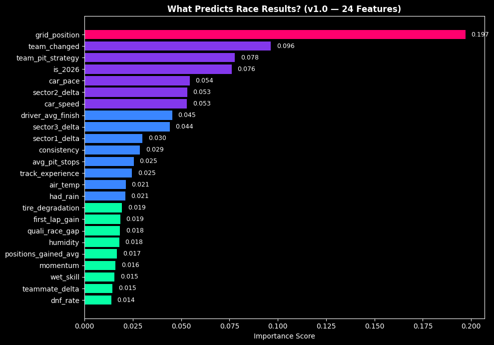

## 5. Japan GP Predictions (v1.0)

The main event — predicted finishing order for Suzuka. Each column tells part of the story: Grid (actual qualifying position), Car (blended pace from all sessions), Spd (speed traps), Skill (teammate delta), Lap1 (first-corner performance), Tire (degradation rate), and Mom (improving/declining/stable).

Qualifying data is now integrated — actual grid positions, live Suzuka sector deltas, and 5-way blended car pace (10% season + 15% FP1 + 20% FP2 + 20% FP3 + 35% qualifying).

```
====================================================================================================
  🏁 PREDICTED FINISH — 2026 JAPANESE GP (v1.0 + Qualifying Data)
====================================================================================================

  Pos  Driver                  Team              Grid   Car   Spd   Skill   Lap1    Tire    Mom   Pred  ΔGrid
  ----------------------------------------------------------------------------------------------------
  P 1  Kimi Antonelli          Mercedes          P 1  P 2  284    +4.8   -1.1  -0.061   ➡️  P 1.4      =
  P 2  Charles Leclerc         Ferrari           P 4  P 5  284    -0.2   +0.9  -0.023    📉  P 2.5     +2
  P 3  Lewis Hamilton          Ferrari           P 6  P 5  284    +0.2   +1.0  +0.082    📈  P 4.0     +3
  P 4  George Russell          Mercedes          P 2  P 2  284    -4.8   -0.8  -0.017    📉  P 4.5     -2
  P 5  Lando Norris            McLaren           P 5  P 5  285    +1.2   +0.1  -0.022    📉  P 4.6      =
  P 6  Oscar Piastri           McLaren           P 3  P 5  285    -1.2   -0.8  -0.055    📈  P 5.3     -3
  P 7  Isack Hadjar            Red Bull Racing   P 8  P10  287    -5.8   -0.2  -0.041    📈  P 6.8     +1
  P 8  Pierre Gasly            Alpine            P 7  P13  285    +0.2   +0.4  -0.071   ➡️  P 6.9     -1
  P 9  Max Verstappen          Red Bull Racing   P11  P10  287    +5.8   -0.1  -0.007    📉  P 7.7     +2
  P10  Arvid Lindblad          Racing Bulls      P10  P11  287    -2.8   +2.6  -0.047   ➡️  P 8.4      =
  P11  Liam Lawson             Racing Bulls      P14  P11  287    +2.8   +0.6  -0.034    📈  P 9.6     +3
  P12  Gabriel Bortoleto       Audi              P 9  P12  285    +1.4   -0.6  -0.025    📈  P10.8     -3
  P13  Esteban Ocon            Haas F1 Team      P12  P13  283    -1.4   +1.2  -0.095    📈  P11.4     -1
  P14  Nico Hulkenberg         Audi              P13  P12  285    -1.4   -0.9  -0.066   ➡️  P11.7     -1
  P15  Carlos Sainz            Williams          P16  P15  289    +5.6   +1.1  -0.023    📉  P12.5     +1
  P16  Oliver Bearman          Haas F1 Team      P18  P13  283    +1.4   +0.4  -0.035    📉  P12.5     +2
  P17  Fernando Alonso         Aston Martin      P21  P21  279     0.0   +1.3  -0.088    📈  P13.4     +4
  P18  Franco Colapinto        Alpine            P15  P13  285    -0.2   +0.8  -0.054   ➡️  P13.9     -3
  P19  Lance Stroll            Aston Martin      P22  P21  279     0.0   +1.1  -0.011    📈  P15.6     +3
  P20  Alexander Albon         Williams          P17  P15  289    -5.6   +0.4  -0.054    📈  P15.8     -3
  P21  Sergio Perez            Cadillac          P19  P19  286    +0.8   +1.5  -0.131   ➡️  P15.9     -2
  P22  Valtteri Bottas         Cadillac          P20  P19  286    -0.8   +1.0  +0.016    📉  P17.2     -2
```

## 6. Rain Scenario

Suzuka has been dry for the last 2 Japanese GPs, but 2023 had a safety car and rain is always possible in March. This shows how predictions shift in wet conditions — some drivers gain positions in the rain (strong wet-weather skills) while others lose out. Green arrows = gains in rain, red = loses.

```
======================================================================
  🌧️ RAIN SCENARIO
======================================================================

  Driver                  Team                Dry    Wet    Shift
  ------------------------------------------------------------
  🟢 Sergio Perez            Cadillac          P15.9  P14.7     +1.3
  🟢 Lance Stroll            Aston Martin      P15.6  P14.5     +1.1
  🟢 Valtteri Bottas         Cadillac          P17.2  P16.2     +1.0
  🟢 Alexander Albon         Williams          P15.8  P14.9     +0.8
  🟢 Fernando Alonso         Aston Martin      P13.4  P12.7     +0.7
  🟢 Arvid Lindblad          Racing Bulls      P8.4  P7.7     +0.7
  🟢 Gabriel Bortoleto       Audi              P10.8  P10.1     +0.6
  🟢 Liam Lawson             Racing Bulls      P9.6  P8.9     +0.6
  ⚪ Carlos Sainz            Williams          P12.5  P12.2     +0.3
  ⚪ Franco Colapinto        Alpine            P13.9  P13.6     +0.3
  ⚪ Isack Hadjar            Red Bull Racing   P6.8  P6.7     +0.1
  ⚪ Oliver Bearman          Haas F1 Team      P12.5  P12.5     +0.1
  ⚪ Esteban Ocon            Haas F1 Team      P11.4  P11.5     -0.0
  ⚪ Kimi Antonelli          Mercedes          P1.4  P1.9     -0.5
  🔴 Max Verstappen          Red Bull Racing   P7.7  P8.3     -0.6
  🔴 Nico Hulkenberg         Audi              P11.7  P12.3     -0.6
  🔴 George Russell          Mercedes          P4.5  P5.3     -0.8
  🔴 Charles Leclerc         Ferrari           P2.5  P3.8     -1.2
  🔴 Lando Norris            McLaren           P4.6  P6.0     -1.4
  🔴 Pierre Gasly            Alpine            P6.9  P8.8     -1.9
  🔴 Oscar Piastri           McLaren           P5.3  P7.7     -2.4
  🔴 Lewis Hamilton          Ferrari           P4.0  P6.5     -2.5
```

## 7. Podium Probabilities (10,000 Simulated Races)

Instead of just predicting one outcome, we simulate the race 10,000 times with realistic randomness — mechanical failures, safety cars (33% chance at Suzuka), first-lap incidents, and general chaos. Then we count how often each driver ends up on the podium. This gives us probabilities rather than a single prediction, which better reflects how unpredictable F1 actually is.

```
  🎲 PODIUM PROBABILITIES (10,000 Simulated Races)
=====================================================================================
  Grid-aware variance: P1-3 ×0.7, P4-7 ×0.9, P8-15 ×1.2, P16+ ×1.0
  Safety car: 33% chance (Suzuka historical)

  Driver                  Team              Grid     Win   Podium   Top 5   Top 10
  --------------------------------------------------------------------------
  Kimi Antonelli          Mercedes          P 1   44.2%    85.7%   96.3%   100.0%  ██████████████████████
  Charles Leclerc         Ferrari           P 4   25.0%    63.7%   83.9%    99.3%  ████████████
  Lewis Hamilton          Ferrari           P 6   12.4%    43.8%   69.5%    98.1%  ██████
  Lando Norris            McLaren           P 5    5.8%    28.5%   55.9%    95.5%  ██
  Isack Hadjar            Red Bull Racing   P 8    3.7%    13.8%   28.4%    75.1%  █
  George Russell          Mercedes          P 2    3.3%    24.7%   57.1%    98.4%  █
  Max Verstappen          Red Bull Racing   P11    1.6%     8.3%   19.1%    65.4%
  Oscar Piastri           McLaren           P 3    1.4%    14.2%   40.3%    96.3%
  Pierre Gasly            Alpine            P 7    1.0%     7.4%   21.5%    80.2%
  Arvid Lindblad          Racing Bulls      P10    1.0%     5.5%   13.5%    57.0%
  Liam Lawson             Racing Bulls      P14    0.4%     2.3%    6.5%    41.0%
  Gabriel Bortoleto       Audi              P 9    0.1%     1.0%    3.2%    27.2%
  Nico Hulkenberg         Audi              P13    0.1%     0.4%    1.6%    18.2%
  Esteban Ocon            Haas F1 Team      P12    0.1%     0.6%    2.1%    20.5%
  Carlos Sainz            Williams          P16    0.0%     0.0%    0.2%     8.0%
```

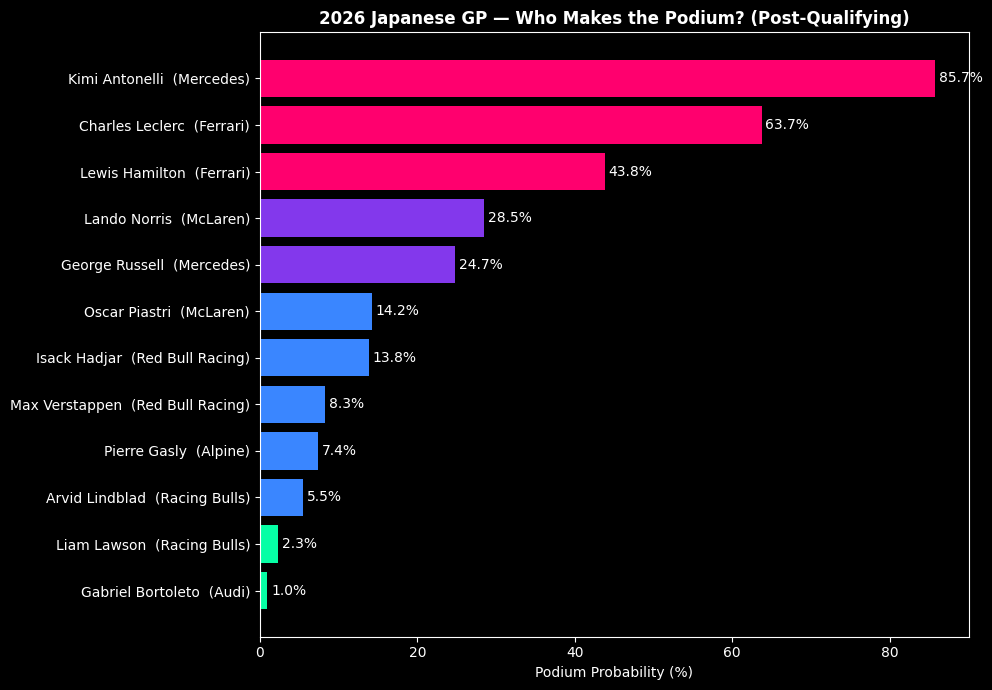

## 8. Teammate Battles

The best measure of a driver's skill is how they perform against their teammate — same car, same strategy options, same pit crew. These head-to-head probabilities come from the 10,000 simulations and show who's likely to beat who within each team.

```
============================================================
  🤝 TEAMMATE HEAD-TO-HEAD
============================================================

  Alpine
  Pierre Gasly         ██████████████████████████████████████░░     Franco Colapinto
                 96.0%                                          4.0%

  Aston Martin
  Fernando Alonso      █████████████████████████████░░░░░░░░░░░         Lance Stroll
                 72.8%                                          27.2%

  Audi
  Gabriel Bortoleto    ███████████████████████░░░░░░░░░░░░░░░░░      Nico Hulkenberg
                 58.6%                                          41.4%

  Cadillac
  Sergio Perez         █████████████████████████░░░░░░░░░░░░░░░      Valtteri Bottas
                 63.8%                                          36.2%

  Ferrari
  Charles Leclerc      █████████████████████████░░░░░░░░░░░░░░░       Lewis Hamilton
                 63.2%                                          36.8%

  Haas F1 Team
  Esteban Ocon         ████████████████████████░░░░░░░░░░░░░░░░       Oliver Bearman
                 60.9%                                          39.1%

  McLaren
  Lando Norris         ███████████████████████░░░░░░░░░░░░░░░░░        Oscar Piastri
                 59.6%                                          40.4%

  Mercedes
  Kimi Antonelli       ███████████████████████████████████░░░░░       George Russell
                 88.8%                                          11.2%

  Racing Bulls
  Arvid Lindblad       ████████████████████████░░░░░░░░░░░░░░░░          Liam Lawson
                 60.3%                                          39.7%

  Red Bull Racing
  Isack Hadjar         ███████████████████████░░░░░░░░░░░░░░░░░       Max Verstappen
                 57.8%                                          42.2%

  Williams
  Carlos Sainz         ████████████████████████████████░░░░░░░░      Alexander Albon
                 81.4%                                          18.6%
```

## 9. F1 Fantasy Picks

Translating race predictions into F1 Fantasy strategy. The key insight: **value matters more than raw points**. A cheap driver who scores 12 points is better for your team than an expensive driver who scores 25 points, because the budget you save lets you upgrade elsewhere. The ⭐ marks the best value picks.

```
=====================================================================================
  🏆 F1 FANTASY PICKS — Japan GP (v1.0)
=====================================================================================

  Driver                  Team              Pred   Race   Qual  Bonus   TOTAL   ~$M  Value
  ----------------------------------------------------------------------------------
  Kimi Antonelli          Mercedes          P 1   19.5     10    0.0   29.5  $ 24  1.24  ⭐
  Charles Leclerc         Ferrari           P 2   15.9      7    1.1   24.0  $ 23  1.02
  Lewis Hamilton          Ferrari           P 3   12.7      5    2.4   20.1  $ 23  0.88
  George Russell          Mercedes          P 4   10.2      9    0.0   19.2  $ 28  0.68
  Lando Norris            McLaren           P 5   10.2      6    0.0   16.2  $ 27  0.60
  Oscar Piastri           McLaren           P 6    8.1      8    0.0   16.1  $ 25  0.65
  Pierre Gasly            Alpine            P 8    5.2      4    0.0    9.2  $ 13  0.72
  Isack Hadjar            Red Bull Racing   P 7    6.1      3    0.1    9.2  $ 14  0.66
  Max Verstappen          Red Bull Racing   P 9    4.5      0    3.0    7.5  $ 28  0.27
  Fernando Alonso         Aston Martin      P17    0.1      0    7.2    7.3  $  9  0.83
  Liam Lawson             Racing Bulls      P11    2.0      0    3.9    5.9  $  7  0.86
  Lance Stroll            Aston Martin      P19    0.0      0    5.0    5.0  $  7  0.73
  Arvid Lindblad          Racing Bulls      P10    3.4      1    0.2    4.6  $  7  0.62
  Oliver Bearman          Haas F1 Team      P16    0.2      0    4.3    4.6  $  9  0.53
  Gabriel Bortoleto       Audi              P12    1.1      2    0.0    3.1  $  6  0.49
  Carlos Sainz            Williams          P15    0.2      0    1.3    1.5  $ 12  0.13
  Esteban Ocon            Haas F1 Team      P13    0.8      0    0.0    0.8  $  8  0.09
  Nico Hulkenberg         Audi              P14    0.7      0    0.0    0.7  $  6  0.12
  Franco Colapinto        Alpine            P18    0.2      0    0.0    0.2  $  7  0.02
  Alexander Albon         Williams          P20    0.0      0    0.0    0.0  $ 11  0.00
  Sergio Perez            Cadillac          P21    0.0      0    0.0    0.0  $  6  0.00
  Valtteri Bottas         Cadillac          P22    0.0      0    0.0    0.0  $  5  0.00

  💡 PICKS:
  🔥 Best value:
     → Kimi Antonelli         (Mercedes) — 29.5 pts / $23.8M = 1.24
     → Charles Leclerc        (Ferrari) — 24.0 pts / $23.4M = 1.02
     → Lewis Hamilton         (Ferrari) — 20.1 pts / $22.9M = 0.88
     → Liam Lawson            (Racing Bulls) — 5.9 pts / $6.9M = 0.86
     → Fernando Alonso        (Aston Martin) — 7.3 pts / $8.8M = 0.83

  🚀 2x Boost: Kimi Antonelli — 29.5 × 2 = 59.1

  🏗️ CONSTRUCTORS:
  Constructor             Season    R03     $M  S.Val  R.Val
  -------------------------------------------------------
  Mercedes                  211   48.7  $29.9   7.06   1.63  ⭐
  Ferrari                   188   44.1  $23.9   7.87   1.84  ⭐
  Haas F1 Team               99    5.3  $ 8.6  11.51   0.62  ⭐
  Red Bull Racing            87   16.6  $28.8   3.02   0.58
  Racing Bulls               85   10.5  $ 7.5  11.33   1.40  ⭐
  Alpine                     67    9.4  $13.7   4.89   0.69
  Williams                   42    1.6  $13.2   3.18   0.12
  McLaren                    12   32.3  $28.5   0.42   1.13
  Cadillac                    9    0.0  $ 5.2   1.73   0.00
  Audi                       -4    3.8  $ 5.4  -0.74   0.70
  Aston Martin              -58   12.3  $ 9.1  -6.37   1.35

  🔥 Best value constructors (season pts / price):
     → Haas F1 Team           — 99 pts / $8.6M = 11.51
     → Racing Bulls           — 85 pts / $7.5M = 11.33
     → Ferrari                — 188 pts / $23.9M = 7.87
```

## 10. My Fantasy Teams

Analysis of my two actual F1 Fantasy teams with specific transfer recommendations based on the model's predictions. Each suggestion shows the points gained, cost impact, and remaining budget.

```
===========================================================================
  📋 RUSSELLIN' FOR POSITION
  Transfers: 0 | Cap: $0.3M
===========================================================================

  Driver                      $    Bst   Pred     Pts       2x    Val
  ------------------------------------------------------------
  George Russell          $28.0         P  4   19.2    19.2  0.68
  Lewis Hamilton          $22.9         P  3   20.1    20.1  0.88
  Kimi Antonelli          $23.8    2x⚡  P  1   29.5    59.1  1.24
  Oliver Bearman          $ 8.6         P 16    4.6     4.6  0.53
  Valtteri Bottas         $ 4.7         P 22    0.0     0.0  0.00

  Constructor                 $    Szn            R03             Val
  ------------------------------------------------------------
  Racing Bulls            $ 7.5     85          10.5           11.33
  Cadillac                $ 5.2      9           0.0           1.73

  📊 PROJECTED: 113.4 pts (Drivers: 102.9 + Constructors: 10.5)

  🔄 TRANSFERS:

  📈 CONSTRUCTOR UPGRADE PATHS:
  Cadillac → Haas F1 Team      + 90 szn pts  need $3.1M freed
  Cadillac → Williams          + 33 szn pts  need $7.7M freed
  Cadillac → Alpine            + 58 szn pts  need $8.2M freed
  Racing Bulls → Haas F1 Team      + 14 szn pts  need $0.8M freed
  Racing Bulls → Ferrari           +103 szn pts  need $16.1M freed
  Racing Bulls → Mercedes          +126 szn pts  need $22.1M freed

  ✅ Boost correct on Kimi Antonelli

===========================================================================
  📋 LECLERC ME IF YOU CAN
  Transfers: 0 | Cap: $0.0M
===========================================================================

  Driver                      $    Bst   Pred     Pts       2x    Val
  ------------------------------------------------------------
  George Russell          $28.0         P  4   19.2    19.2  0.68
```

[output cut: 8 more lines]

```
  Cadillac                $ 5.2      9           0.0           1.73

  📊 PROJECTED: 112.9 pts (Drivers: 102.4 + Constructors: 10.5)

  🔄 TRANSFERS:

  📈 CONSTRUCTOR UPGRADE PATHS:
  Cadillac → Haas F1 Team      + 90 szn pts  need $3.4M freed
  Cadillac → Williams          + 33 szn pts  need $8.0M freed
  Cadillac → Alpine            + 58 szn pts  need $8.5M freed
  Racing Bulls → Haas F1 Team      + 14 szn pts  need $1.1M freed
  Racing Bulls → Ferrari           +103 szn pts  need $16.4M freed
  Racing Bulls → Mercedes          +126 szn pts  need $22.4M freed

  ✅ Boost correct on Kimi Antonelli
```

### Confidence: HIGH (post-qualifying)

| Version | Features | Key Addition | Confidence |
| --- | --- | --- | --- |
| v0.1 | 3 | ELO baseline | LOW |
| v0.2 | 9 | Regulation-aware weighting | LOW-MEDIUM |
| v0.3 | 9 | XGBoost ML | MEDIUM |
| v0.4 | 15 | Two-model approach + weather | MEDIUM |
| v0.5 | 15 | Speed traps + lap consistency | MEDIUM |
| v0.6 | 18 | First lap + tire degradation + momentum | MEDIUM |
| v0.7 | 21 | Suzuka sectors + safety car sim | MEDIUM-HIGH |
| v0.8 | 21 | 2026 weighted 10x (car > driver fix) | MEDIUM-HIGH |
| v0.9 | 22 | Honest validation + team change flag | MEDIUM-HIGH |
| v1.0 | 24 | Tire strategy + practice data | MEDIUM-HIGH |
| **v1.0+Q** | **24** | **Actual qualifying grid + live sectors + 5-way car pace + position-dependent sims** | **HIGH** |

**What changed from pre-qualifying:**

- Grid positions: estimated from season averages → actual P1-P22 from qualifying
- Sector deltas: 2023-2024 historical Suzuka → live 2026 qualifying sectors
- Car pace: 3-way blend (season/FP1/FP2) → 5-way blend (+FP3 +qualifying, 35% quali weight)
- Speed traps: FP1/FP2 only → includes qualifying max attack speeds
- Simulation: uniform variance → grid-position-dependent (front row tighter, midfield wider)
- Fantasy: estimated quali positions → actual qualifying results for scoring
- Weather: FP2 conditions → qualifying conditions (16.5°C, 52% humidity, dry)

**Remaining uncertainty:**

- Race day weather could change (forecast is dry but Suzuka is unpredictable)
- Safety car timing and VSC periods (modeled as 33% probability)
- Tire strategy choices (1-stop vs 2-stop) not yet race-specific
- First lap incidents — modeled statistically but inherently random
- Post-race: accuracy analysis to calibrate for future races

## 11. Race Results & Model Accuracy

The race has run — time to grade the model. This section pulls the official classification and compares it against the post-qualifying predictions above: position-by-position error, top 5 / top 10 accuracy, podium hits, and where the model beat or missed. These accuracy numbers feed the season scoreboard and calibrate future race simulations.

[output not shown]

[output not shown]

[output not shown]

[output not shown]

[output not shown]

[output not shown]

[output not shown]

[output not shown]

[output not shown]

[output not shown]

[output not shown]

[output not shown]

[output not shown]

[output not shown]

```
===============================================================================================
  🏁 OFFICIAL RESULTS vs MODEL — 2026 JAPANESE GP
===============================================================================================

  Fin  Driver                  Team              Grid  Pred   Err  Status
  --------------------------------------------------------------------------------
  P 1  Kimi Antonelli          Mercedes          P 1  P 1     0  Finished 🎯
  P 2  Oscar Piastri           McLaren           P 3  P 6     4  Finished
  P 3  Charles Leclerc         Ferrari           P 4  P 2     1  Finished
  P 4  George Russell          Mercedes          P 2  P 4     0  Finished 🎯
  P 5  Lando Norris            McLaren           P 5  P 5     0  Finished 🎯
  P 6  Lewis Hamilton          Ferrari           P 6  P 3     3  Finished
  P 7  Pierre Gasly            Alpine            P 7  P 8     1  Finished
  P 8  Max Verstappen          Red Bull Racing   P11  P 9     1  Finished
  P 9  Liam Lawson             Racing Bulls      P14  P11     2  Finished
  P10  Esteban Ocon            Haas F1 Team      P12  P13     3  Finished
  P11  Nico Hulkenberg         Audi              P13  P14     3  Finished
  P12  Isack Hadjar            Red Bull Racing   P 8  P 7     5  Finished
  P13  Gabriel Bortoleto       Audi              P 9  P12     1  Finished
  P14  Arvid Lindblad          Racing Bulls      P10  P10     4  Finished
  P15  Carlos Sainz            Williams          P16  P15     0  Finished 🎯
  P16  Franco Colapinto        Alpine            P15  P18     2  Finished
  P17  Sergio Perez            Cadillac          P19  P21     4  Finished
  P18  Fernando Alonso         Aston Martin      P21  P17     1  Lapped
  P19  Valtteri Bottas         Cadillac          P20  P22     3  Lapped
  P20  Alexander Albon         Williams          P17  P20     0  Lapped 🎯
  P21  Lance Stroll            Aston Martin      P22  P19   DNF  Retired
  P22  Oliver Bearman          Haas F1 Team      P18  P16   DNF  Retired

  📊 SCORECARD
  ------------------------------------------------------------
  Predicted winner:  Kimi Antonelli
  Actual winner:     Kimi Antonelli  ✅
  Podium accuracy:   2/3
  Top 5 accuracy:    4/5
  Top 10 accuracy:   8/10
  MAE (classified):  1.90 positions  (validation expected 2.26)

  🏁 vs GRID BASELINE
  Grid-copy MAE:     1.95  (top5 5/5, top10 7/10)
  Model edge:        +0.05  ->  model beats grid

  🎯 Best calls:   Kimi Antonelli (P1→P1), George Russell (P4→P4), Lando Norris (P5→P5)
  💥 Worst misses: Isack Hadjar (pred P7, fin P12), Oscar Piastri (pred P6, fin P2), Arvid Lindblad (pred P10, fin P14)
  🔧 DNFs: Lance Stroll (Retired), Oliver Bearman (Retired)
```

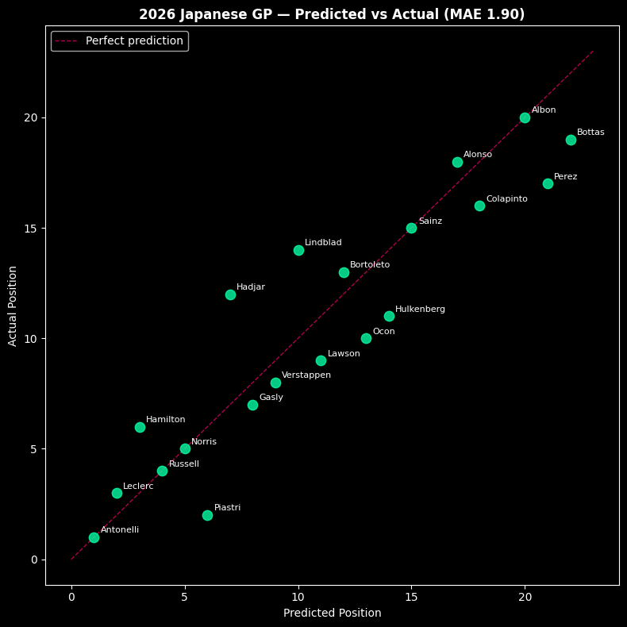